# py_decisionforests_multiclass_crop_mapping_optical_radar

### Multi-Class Model for Crop Mapping with Fused Optical and Radar Data Using TensorFlow Decision Forests

### November 29, 2021

Template Credit: Adapted from a template made available by Dr. Jason Brownlee of Machine Learning Mastery. [https://machinelearningmastery.com/]

SUMMARY: This project aims to construct a predictive model using various machine learning algorithms and document the end-to-end steps using a template. The Crop Mapping with Fused Optical Radar Data dataset is a multi-class modeling situation where we attempt to predict one of several (more than two) possible outcomes.

INTRODUCTION: This dataset combines optical and PolSAR remote sensing images for cropland classification. The organization collected the images using RapidEye satellites (optical) and the Unmanned Aerial Vehicle Synthetic Aperture Radar (UAVSAR) system (radar) over an agricultural region near Winnipeg, Manitoba, Canada, in 2012. There are two sets of 49-radar features and two sets of 38-optical features for 05 and 14 July 2012. Seven crop type classes exist for this data set: 1-Corn; 2-Peas; 3-Canola; 4-Soybeans; 5-Oats; 6-Wheat; and 7-Broadleaf.

CONCLUSION: In this iteration, the TensorFlow Decision Forests model appeared to be a suitable algorithm for modeling this dataset.

Dataset Used: Crop Mapping with Fused Optical Radar Data

Dataset ML Model: Multi-class classification with numerical attributes

Dataset Reference: https://archive-beta.ics.uci.edu/ml/datasets/crop+mapping+using+fused+optical+radar+data+set

## Task 1 - Prepare Environment

```python
# Install the necessary packages for Colab
# !pip install python-dotenv PyMySQL
```

```python
# Installing TFDF might be necessary when using the script with Google Colab
# !pip install tensorflow_decision_forests
```

```python
# For managing screen output when using the script with Google Colab
# !pip install wurlitzer
```

```python
# # Retrieve the GPU information from Colab
# gpu_info = !nvidia-smi
# gpu_info = '\n'.join(gpu_info)
# if gpu_info.find('failed') >= 0:
#     print('Select the Runtime → "Change runtime type" menu to enable a GPU accelerator, ')
#     print('and then re-execute this cell.')
# else:
#     print(gpu_info)
```

```python
# # Retrieve the memory configuration from Colab
# from psutil import virtual_memory
# ram_gb = virtual_memory().total / 1e9
# print('Your runtime has {:.1f} gigabytes of available RAM\n'.format(ram_gb))

# if ram_gb < 20:
#     print('To enable a high-RAM runtime, select the Runtime → "Change runtime type"')
#     print('menu, and then select High-RAM in the Runtime shape dropdown. Then, ')
#     print('re-execute this cell.')
# else:
#     print('You are using a high-RAM runtime!')
```

```python
# # Mount Google Drive locally for loading the dotenv files
# from dotenv import load_dotenv
# from google.colab import drive
# drive.mount('/content/gdrive')
# gdrivePrefix = '/content/gdrive/My Drive/Colab_Downloads/'
# env_path = '/content/gdrive/My Drive/Colab Notebooks/'
# dotenv_path = env_path + "python_script.env"
# load_dotenv(dotenv_path=dotenv_path)
```

```python
# Retrieve the CPU information
ncpu = !nproc
print("The number of available CPUs is:", ncpu[0])
```

```
The number of available CPUs is: 4
```

### 1.a) Load libraries and modules

```python
# Set the random seed number for reproducible results
RNG_SEED = 88
```

```python
import random
random.seed(RNG_SEED)
import numpy as np
np.random.seed(RNG_SEED)
import pandas as pd
import seaborn as sns
import matplotlib.pyplot as plt
import os
import sys
import math
from datetime import datetime
# import boto3
from sklearn import preprocessing
from sklearn.model_selection import train_test_split
from sklearn.model_selection import RepeatedKFold
from sklearn.metrics import classification_report
from sklearn.metrics import confusion_matrix
from sklearn.metrics import accuracy_score

import tensorflow as tf
tf.random.set_seed(RNG_SEED)
from tensorflow import keras
import tensorflow_decision_forests as tfdf
```

```python
# try:
#   from wurlitzer import sys_pipes
# except:
#   from colabtools.googlelog import CaptureLog as sys_pipes

# from IPython.core.magic import register_line_magic
# from IPython.display import Javascript
```

### 1.b) Set up the controlling parameters and functions

```python
# Begin the timer for the script processing
START_TIME_SCRIPT = datetime.now()
```

```python
# Set up the number of CPU cores available for multi-thread processing
N_JOBS = 2

# Set up the flag to stop sending progress emails (setting to True will send status emails!)
NOTIFY_STATUS = False

# Set the percentage sizes for splitting the dataset
TEST_SET_RATIO = 0.2
VAL_SET_RATIO = 0.1

# Set the number of folds for cross validation
N_FOLDS = 5
N_ITERATIONS = 1

# Set various default modeling parameters
DEFAULT_METRICS = ["accuracy", tf.keras.metrics.SparseCategoricalCrossentropy()]

# Define the directory locations and file names
TRAIN_DATASET = 'WinnipegDataset.txt'
TEST_DATASET = 'test.csv'

# # Check the number of GPUs accessible through TensorFlow
# print('Num GPUs Available:', len(tf.config.list_physical_devices('GPU')))

# Print out the TensorFlow version for confirmation
print('TensorFlow version:', tf.__version__)

# Check the version of TensorFlow Decision Forests
print("Found TensorFlow Decision Forests v" + tfdf.__version__)
```

```
TensorFlow version: 2.7.0
Found TensorFlow Decision Forests v0.2.1
```

[output not shown]

```python
# Set up the email notification function
def status_notify(msg_text):
    access_key = os.environ.get('SNS_ACCESS_KEY')
    secret_key = os.environ.get('SNS_SECRET_KEY')
    aws_region = os.environ.get('SNS_AWS_REGION')
    topic_arn = os.environ.get('SNS_TOPIC_ARN')
    if (access_key is None) or (secret_key is None) or (aws_region is None):
        sys.exit("Incomplete notification setup info. Script Processing Aborted!!!")
    sns = boto3.client('sns', aws_access_key_id=access_key, aws_secret_access_key=secret_key, region_name=aws_region)
    response = sns.publish(TopicArn=topic_arn, Message=msg_text)
    if response['ResponseMetadata']['HTTPStatusCode'] != 200 :
        print('Status notification not OK with HTTP status code:', response['ResponseMetadata']['HTTPStatusCode'])
```

```python
# Reset the random number generators
def reset_random(x=RNG_SEED):
    random.seed(x)
    np.random.seed(x)
    tf.random.set_seed(x)
```

```python
if NOTIFY_STATUS: status_notify("Task 1 - Prepare Environment has begun! " + datetime.now().strftime('%a %B %d, %Y %I:%M:%S %p'))
```

### 1.c) Load dataset

```python
if not os.path.exists(TRAIN_DATASET):
    !wget https://dainesanalytics.com/datasets/crop-mapping-winnipeg/WinnipegDataset.txt
```

```python
df_dataset_import = pd.read_csv(TRAIN_DATASET, index_col=False)

# Take a peek at the dataframe after import
print(df_dataset_import.head())
```

```
   label      f1      f2       f3      f4      f5      f6      f7      f8  \
0      1 -13.559 -21.407 -11.4040 -15.248 -11.923 -15.291 -2.1548 -7.8474
1      1 -12.802 -20.335 -10.3990 -14.132 -11.096 -14.361 -2.4039 -7.5330
2      1 -12.431 -19.902 -10.0740 -13.598 -10.829 -14.048 -2.3566 -7.4717
3      1 -12.689 -19.529 -10.0280 -13.350 -11.056 -14.014 -2.6611 -6.8396
4      1 -12.686 -19.278  -9.8185 -13.108 -10.932 -13.939 -2.8675 -6.5919

        f9  ...     f165     f166    f167      f168     f169     f170  \
0 -10.0020  ...  0.18519  0.72602  5.3333  6.000000  0.29489  9.77780
1  -9.9369  ...  0.33333 -0.48751  2.1111  0.098765  0.83333  0.33333
2  -9.8283  ...  0.25926  0.25298  2.2222  0.172840  0.68889  0.88889
3  -9.5006  ...  0.16049  0.43750  4.1111  0.320990  0.83333  0.33333
4  -9.4594  ...  0.18519  0.35000  4.0000  0.444440  0.68889  0.88889

      f171     f172     f173     f174
0  2.44440  1.67700  0.20988  0.65422
1  0.33333  0.84869  0.50617 -0.18898
2  0.66667  1.27300  0.30864  0.10483
3  0.33333  1.14910  0.38272  0.41603
4  0.66667  1.58110  0.20988  0.50000

[5 rows x 175 columns]
```

```python
df_dataset_import.info(verbose=True)
```

```
<class 'pandas.core.frame.DataFrame'>
RangeIndex: 325834 entries, 0 to 325833
Data columns (total 175 columns):
 #    Column  Dtype
---   ------  -----
 0    label   int64
 1    f1      float64
 2    f2      float64
 3    f3      float64
 4    f4      float64
 5    f5      float64
 6    f6      float64
 7    f7      float64
 8    f8      float64
 9    f9      float64
```

[output cut: 167 more lines]

```python
print(df_dataset_import.describe())
```

```
               label             f1             f2             f3  \
count  325834.000000  325834.000000  325834.000000  325834.000000
mean        4.062421     -15.143602     -24.026035     -15.400034
std         1.604617       3.504255       4.054214       3.267857
min         1.000000     -23.971000     -34.308000     -23.161000
25%         3.000000     -17.848000     -27.119000     -17.563000
50%         4.000000     -15.992000     -25.064000     -16.164000
75%         6.000000     -11.786000     -20.387000     -13.427000
max         7.000000       2.535600      -7.589100       1.104000

                 f4             f5             f6             f7  \
count  325834.00000  325834.000000  325834.000000  325834.000000
mean      -18.59383     -14.493472     -18.427329       0.256432
std         3.71163       3.189013       3.675741       1.682060
min       -27.24500     -22.103000     -26.897000      -5.582600
25%       -21.44900     -16.989000     -21.450000      -1.037800
50%       -19.58800     -15.099000     -19.282000       0.309180
75%       -15.65000     -11.735000     -15.514000       1.558200
max         0.77491      -0.887390       0.951780       7.029900

                  f8             f9  ...           f165           f166  \
count  325834.000000  325834.000000  ...  325834.000000  325834.000000
mean       -8.882434      -8.626002  ...       0.433834       0.329085
std         1.204040       2.002658  ...       0.245857       0.442008
min       -16.389000     -16.558000  ...       0.111110      -1.000000
25%        -9.658500     -10.070000  ...       0.259260       0.000000
50%        -8.915900      -8.733100  ...       0.358020       0.357140
75%        -8.190200      -7.158100  ...       0.506170       0.661440
max        -1.175400      -0.924610  ...       1.000000       1.000000

                f167           f168           f169           f170  \
count  325834.000000  325834.000000  325834.000000  325834.000000
mean        2.171177       0.080138       0.919604       0.174447
std         1.284653       0.182628       0.105953       0.373726
min         0.000000       0.000000       0.106190       0.000000
25%         1.000000       0.000000       0.833330       0.000000
50%         2.000000       0.000000       1.000000       0.000000
75%         3.000000       0.172840       1.000000       0.333330
max        12.444000      25.951000       1.000000      66.667000

                f171           f172           f173           f174
count  325834.000000  325834.000000  325834.000000  325834.000000
mean        0.162900       0.403288       0.764646       0.667567
std         0.222008       0.480141       0.273847       0.471260
min         0.000000      -0.000000       0.111110      -1.000000
25%         0.000000       0.000000       0.506170       0.357140
50%         0.000000      -0.000000       1.000000       1.000000
75%         0.333330       0.848690       1.000000       1.000000
max         6.666700       2.197200       1.000000       1.000000

[8 rows x 175 columns]
```

```python
print(df_dataset_import.isnull().sum())
print('Total number of NaN in the dataframe: ', df_dataset_import.isnull().sum().sum())
```

```
label    0
f1       0
f2       0
f3       0
f4       0
        ..
f170     0
f171     0
f172     0
f173     0
f174     0
Length: 175, dtype: int64
Total number of NaN in the dataframe:  0
```

```python
# Get grouping size for the target variable
print(df_dataset_import.groupby('label').size())
```

```
label
1    39162
2     3598
3    75673
4    74067
5    47117
6    85074
7     1143
dtype: int64
```

### 1.d) Data Cleaning

```python
# Standardize the class column to the name of target
df_dataset_import = df_dataset_import.rename(columns={'label':'target'})

# Take a peek at the dataframe after cleaning
print(df_dataset_import.head())
```

```
   target      f1      f2       f3      f4      f5      f6      f7      f8  \
0       1 -13.559 -21.407 -11.4040 -15.248 -11.923 -15.291 -2.1548 -7.8474
1       1 -12.802 -20.335 -10.3990 -14.132 -11.096 -14.361 -2.4039 -7.5330
2       1 -12.431 -19.902 -10.0740 -13.598 -10.829 -14.048 -2.3566 -7.4717
3       1 -12.689 -19.529 -10.0280 -13.350 -11.056 -14.014 -2.6611 -6.8396
4       1 -12.686 -19.278  -9.8185 -13.108 -10.932 -13.939 -2.8675 -6.5919

        f9  ...     f165     f166    f167      f168     f169     f170  \
0 -10.0020  ...  0.18519  0.72602  5.3333  6.000000  0.29489  9.77780
1  -9.9369  ...  0.33333 -0.48751  2.1111  0.098765  0.83333  0.33333
2  -9.8283  ...  0.25926  0.25298  2.2222  0.172840  0.68889  0.88889
3  -9.5006  ...  0.16049  0.43750  4.1111  0.320990  0.83333  0.33333
4  -9.4594  ...  0.18519  0.35000  4.0000  0.444440  0.68889  0.88889

      f171     f172     f173     f174
0  2.44440  1.67700  0.20988  0.65422
1  0.33333  0.84869  0.50617 -0.18898
2  0.66667  1.27300  0.30864  0.10483
3  0.33333  1.14910  0.38272  0.41603
4  0.66667  1.58110  0.20988  0.50000

[5 rows x 175 columns]
```

```python
df_dataset_import.info(verbose=True)
```

```
<class 'pandas.core.frame.DataFrame'>
RangeIndex: 325834 entries, 0 to 325833
Data columns (total 175 columns):
 #    Column  Dtype
---   ------  -----
 0    target  int64
 1    f1      float64
 2    f2      float64
 3    f3      float64
 4    f4      float64
 5    f5      float64
 6    f6      float64
 7    f7      float64
 8    f8      float64
 9    f9      float64
```

[output cut: 167 more lines]

```python
print(df_dataset_import.describe())
```

```
              target             f1             f2             f3  \
count  325834.000000  325834.000000  325834.000000  325834.000000
mean        4.062421     -15.143602     -24.026035     -15.400034
std         1.604617       3.504255       4.054214       3.267857
min         1.000000     -23.971000     -34.308000     -23.161000
25%         3.000000     -17.848000     -27.119000     -17.563000
50%         4.000000     -15.992000     -25.064000     -16.164000
75%         6.000000     -11.786000     -20.387000     -13.427000
max         7.000000       2.535600      -7.589100       1.104000

                 f4             f5             f6             f7  \
count  325834.00000  325834.000000  325834.000000  325834.000000
mean      -18.59383     -14.493472     -18.427329       0.256432
std         3.71163       3.189013       3.675741       1.682060
min       -27.24500     -22.103000     -26.897000      -5.582600
25%       -21.44900     -16.989000     -21.450000      -1.037800
50%       -19.58800     -15.099000     -19.282000       0.309180
75%       -15.65000     -11.735000     -15.514000       1.558200
max         0.77491      -0.887390       0.951780       7.029900

                  f8             f9  ...           f165           f166  \
count  325834.000000  325834.000000  ...  325834.000000  325834.000000
mean       -8.882434      -8.626002  ...       0.433834       0.329085
std         1.204040       2.002658  ...       0.245857       0.442008
min       -16.389000     -16.558000  ...       0.111110      -1.000000
25%        -9.658500     -10.070000  ...       0.259260       0.000000
50%        -8.915900      -8.733100  ...       0.358020       0.357140
75%        -8.190200      -7.158100  ...       0.506170       0.661440
max        -1.175400      -0.924610  ...       1.000000       1.000000

                f167           f168           f169           f170  \
count  325834.000000  325834.000000  325834.000000  325834.000000
mean        2.171177       0.080138       0.919604       0.174447
std         1.284653       0.182628       0.105953       0.373726
min         0.000000       0.000000       0.106190       0.000000
25%         1.000000       0.000000       0.833330       0.000000
50%         2.000000       0.000000       1.000000       0.000000
75%         3.000000       0.172840       1.000000       0.333330
max        12.444000      25.951000       1.000000      66.667000

                f171           f172           f173           f174
count  325834.000000  325834.000000  325834.000000  325834.000000
mean        0.162900       0.403288       0.764646       0.667567
std         0.222008       0.480141       0.273847       0.471260
min         0.000000      -0.000000       0.111110      -1.000000
25%         0.000000       0.000000       0.506170       0.357140
50%         0.000000      -0.000000       1.000000       1.000000
75%         0.333330       0.848690       1.000000       1.000000
max         6.666700       2.197200       1.000000       1.000000

[8 rows x 175 columns]
```

```python
print(df_dataset_import.isnull().sum())
print('Total number of NaN in the dataframe: ', df_dataset_import.isnull().sum().sum())
```

```
target    0
f1        0
f2        0
f3        0
f4        0
         ..
f170      0
f171      0
f172      0
f173      0
f174      0
Length: 175, dtype: int64
Total number of NaN in the dataframe:  0
```

```python
# Get grouping size for the target variable
print(df_dataset_import.groupby('target').size())
```

```
target
1    39162
2     3598
3    75673
4    74067
5    47117
6    85074
7     1143
dtype: int64
```

### 1.e) Splitting Data into Sets

```python
# Use variable total_column_count to hold the number of columns in the dataframe
total_column_count = len(df_dataset_import.columns)

# Set up variable total_feature_count for the total number of attribute columns
total_feature_count = total_column_count-1

# We create attribute-only and target-only datasets (df_features_train and df_target_train)
df_target_import = df_dataset_import['target']
df_features_import = df_dataset_import.drop(['target'], axis=1)

print("df_dataset_import.shape: {} df_features_import.shape: {} df_target_import.shape: {}".format(df_dataset_import.shape, df_features_import.shape, df_target_import.shape))
```

```
df_dataset_import.shape: (325834, 175) df_features_import.shape: (325834, 174) df_target_import.shape: (325834,)
```

```python
# Split the data further into training and test datasets
df_features_train, df_features_test, df_target_train, df_target_test = train_test_split(df_features_import, df_target_import,
                                                                                        test_size=TEST_SET_RATIO, random_state=RNG_SEED)
print("df_features_train.shape: {} df_target_train.shape: {}".format(df_features_train.shape, df_target_train.shape))
print("df_features_test.shape: {} df_target_test.shape: {}".format(df_features_test.shape, df_target_test.shape))
```

```
df_features_train.shape: (260667, 174) df_target_train.shape: (260667,)
df_features_test.shape: (65167, 174) df_target_test.shape: (65167,)
```

### 1.f) Set up the parameters for data visualization

```python
# Set up the number of row and columns for visualization display. display_rows * display_columns should be >= total_feature_count
display_columns = 4
if total_feature_count % display_columns == 0 :
    display_rows = total_feature_count // display_columns
else :
    display_rows = (total_feature_count // display_columns) + 1

# Set figure width to display the data visualization plots
fig_size = plt.rcParams["figure.figsize"]
fig_size[0] = display_columns * 4
fig_size[1] = display_rows * 4
plt.rcParams["figure.figsize"] = fig_size
```

```python
if NOTIFY_STATUS: status_notify("Task 1 - Prepare Environment completed! "+datetime.now().strftime('%a %B %d, %Y %I:%M:%S %p'))
```

## Task 2 - Summarize and Visualize Data

```python
if NOTIFY_STATUS: status_notify("Task 2 - Summarize and Visualize Data has begun! "+datetime.now().strftime('%a %B %d, %Y %I:%M:%S %p'))
```

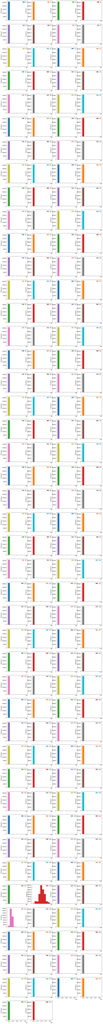

```python
# Histograms for each attribute
df_features_train.plot(kind='hist', subplots=True, layout=(display_rows, display_columns))
plt.show()
```

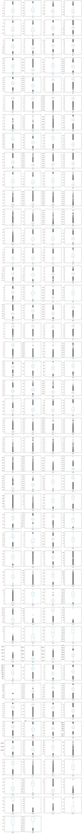

```python
# Box and Whisker plot for each attribute
df_features_train.plot(kind='box', subplots=True, layout=(display_rows, display_columns))
plt.show()
```

```python
# # Correlation matrix
# fig = plt.figure(figsize=(20, 20))
# correlations = df_features_train.corr(method='pearson')
# sns.heatmap(correlations, annot=True, cmap=plt.cm.PuBu)
# plt.show()
```

```python
if NOTIFY_STATUS: status_notify("Task 2 - Summarize and Visualize Data completed! "+datetime.now().strftime('%a %B %d, %Y %I:%M:%S %p'))
```

## Task 3 - Train and Evaluate Models

```python
if NOTIFY_STATUS: status_notify("Task 3 - Train and Evaluate Models has begun! "+datetime.now().strftime('%a %B %d, %Y %I:%M:%S %p'))
```

### 3.a) Splitting Data into Training and Validation Sets

```python
# Split the data further into training and validation datasets
df_dataset_train, df_dataset_valid = train_test_split(df_dataset_import, test_size=VAL_SET_RATIO, random_state=RNG_SEED)
print("df_dataset_train.shape: {} df_dataset_valid.shape: {}".format(df_dataset_train.shape, df_dataset_valid.shape))
```

```
df_dataset_train.shape: (293250, 175) df_dataset_valid.shape: (32584, 175)
```

```python
# Finalize the training and validation datasets for the modeling activities
tfds_train = tfdf.keras.pd_dataframe_to_tf_dataset(df_dataset_train, label='target', task=tfdf.keras.Task.CLASSIFICATION)
tfds_valid = tfdf.keras.pd_dataframe_to_tf_dataset(df_dataset_valid, label='target', task=tfdf.keras.Task.CLASSIFICATION)
```

### 3.b) Train and Evaluate the Random Forest Model

```python
# Define the baseline model for benchmarking
START_TIME_MODULE = datetime.now()
reset_random()
RF_model = tfdf.keras.RandomForestModel(task=tfdf.keras.Task.CLASSIFICATION)
RF_model.compile(metrics=DEFAULT_METRICS)

# "sys_pipes" is optional. It enables the display of the training logs.
# with sys_pipes():
#     RF_model.fit(x=tfds_train)

# Train the model.
RF_model.fit(x=tfds_train)
print ('Model training time:', (datetime.now() - START_TIME_MODULE), '\n')
```

[output not shown]

[output cut: 446 more lines]

```
[INFO random_forest.cc:628] Training of tree  271/300 (tree index:269) done accuracy:0.996177 logloss:0.0192825
[INFO random_forest.cc:628] Training of tree  274/300 (tree index:274) done accuracy:0.996153 logloss:0.01928
[INFO random_forest.cc:628] Training of tree  278/300 (tree index:277) done accuracy:0.99614 logloss:0.0192866
[INFO random_forest.cc:628] Training of tree  281/300 (tree index:279) done accuracy:0.996184 logloss:0.0192934
[INFO random_forest.cc:628] Training of tree  285/300 (tree index:285) done accuracy:0.996164 logloss:0.0192905
[INFO random_forest.cc:628] Training of tree  291/300 (tree index:291) done accuracy:0.996181 logloss:0.0192829
[INFO random_forest.cc:628] Training of tree  296/300 (tree index:295) done accuracy:0.996208 logloss:0.0192814
[INFO random_forest.cc:628] Training of tree  300/300 (tree index:299) done accuracy:0.996198 logloss:0.0192788
[INFO random_forest.cc:696] Final OOB metrics: accuracy:0.996198 logloss:0.0192788
[INFO kernel.cc:828] Export model in log directory: /tmp/tmpw1hb5eic
[INFO kernel.cc:836] Save model in resources
[INFO kernel.cc:988] Loading model from path
[INFO decision_forest.cc:590] Model loaded with 300 root(s), 739528 node(s), and 174 input feature(s).
[INFO abstract_model.cc:993] Engine "RandomForestGeneric" built
[INFO kernel.cc:848] Use fast generic engine
```

```
Model training time: 0:21:52.776021
```

```python
RF_eval = RF_model.evaluate(tfds_valid, return_dict=True)
print()

for name, value in RF_eval.items():
    print(f"{name}: {value:.4f}")
```

```
loss: 0.0000
accuracy: 0.9963
sparse_categorical_crossentropy: 0.0187
```

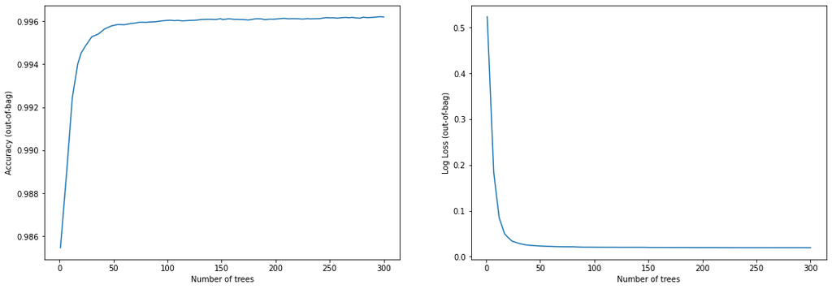

```python
logs = RF_model.make_inspector().training_logs()

plt.figure(figsize=(18, 6))
plt.subplot(1, 2, 1)
plt.plot([log.num_trees for log in logs], [log.evaluation.accuracy for log in logs])
plt.xlabel("Number of trees")
plt.ylabel("Accuracy (out-of-bag)")
plt.subplot(1, 2, 2)
plt.plot([log.num_trees for log in logs], [log.evaluation.loss for log in logs])
plt.xlabel("Number of trees")
plt.ylabel("Log Loss (out-of-bag)")
plt.show()
```

```python
# Plot the model using Google Colab
# tfdf.model_plotter.plot_model_in_colab(RF_model)
```

### 3.c) Train and Evaluate the Decision Trees Model

```python
# Define the baseline model for benchmarking
START_TIME_MODULE = datetime.now()
reset_random()
CART_model = tfdf.keras.CartModel(task=tfdf.keras.Task.CLASSIFICATION)
CART_model.compile(metrics=DEFAULT_METRICS)

# "sys_pipes" is optional. It enables the display of the training logs.
# with sys_pipes():
#     CART_model.fit(x=tfds_train)

# Train the model.
CART_model.fit(x=tfds_train)
print ('Model training time:', (datetime.now() - START_TIME_MODULE), '\n')
```

[output not shown]

[output cut: 358 more lines]

```
    num_candidate_attributes_ratio: -1
    axis_aligned_split {
    }
    internal {
      sorting_strategy: PRESORTED
    }
  }
  validation_ratio: 0.1
}

[INFO kernel.cc:790] Deployment config:
num_threads: 6

[INFO kernel.cc:817] Train model
[INFO cart.cc:174] Training CART on 293250 example(s) and 174 feature(s).
```

```
[INFO cart.cc:375] 2723 nodes before pruning. 1061 nodes after pruning.
[INFO kernel.cc:828] Export model in log directory: /tmp/tmppyav3zal
[INFO kernel.cc:836] Save model in resources
[INFO kernel.cc:988] Loading model from path
[INFO decision_forest.cc:590] Model loaded with 1 root(s), 1061 node(s), and 155 input feature(s).
[INFO abstract_model.cc:993] Engine "RandomForestGeneric" built
[INFO kernel.cc:848] Use fast generic engine
```

```
Model training time: 0:03:11.409133
```

```python
CART_eval = CART_model.evaluate(tfds_valid, return_dict=True)
print()

for name, value in CART_eval.items():
    print(f"{name}: {value:.4f}")
```

```
loss: 0.0000
accuracy: 0.9858
sparse_categorical_crossentropy: 0.0480
```

```python
# Plot the model using Google Colab
# tfdf.model_plotter.plot_model_in_colab(CART_model)
```

### 3.d) Train and Evaluate the Gradient Boosted Trees Model

```python
# Define the baseline model for benchmarking
START_TIME_MODULE = datetime.now()
reset_random()
GBT_model = tfdf.keras.GradientBoostedTreesModel(task=tfdf.keras.Task.CLASSIFICATION)
GBT_model.compile(metrics=DEFAULT_METRICS)

# "sys_pipes" is optional. It enables the display of the training logs.
# with sys_pipes():
#     GBT_model.fit(x=tfds_train)

# Train the model.
GBT_model.fit(x=tfds_train)
print ('Model training time:', (datetime.now() - START_TIME_MODULE), '\n')
```

[output not shown]

[output cut: 534 more lines]

```
[INFO gradient_boosted_trees.cc:1428] 	num-trees:282 train-loss:0.000768 train-accuracy:0.999943 valid-loss:0.007572 valid-accuracy:0.997453
[INFO gradient_boosted_trees.cc:1428] 	num-trees:284 train-loss:0.000753 train-accuracy:0.999943 valid-loss:0.007546 valid-accuracy:0.997419
[INFO gradient_boosted_trees.cc:1428] 	num-trees:286 train-loss:0.000740 train-accuracy:0.999943 valid-loss:0.007543 valid-accuracy:0.997453
[INFO gradient_boosted_trees.cc:1428] 	num-trees:288 train-loss:0.000725 train-accuracy:0.999943 valid-loss:0.007512 valid-accuracy:0.997521
[INFO gradient_boosted_trees.cc:1428] 	num-trees:290 train-loss:0.000713 train-accuracy:0.999943 valid-loss:0.007497 valid-accuracy:0.997521
[INFO gradient_boosted_trees.cc:1428] 	num-trees:292 train-loss:0.000700 train-accuracy:0.999943 valid-loss:0.007469 valid-accuracy:0.997521
[INFO gradient_boosted_trees.cc:1428] 	num-trees:294 train-loss:0.000688 train-accuracy:0.999943 valid-loss:0.007466 valid-accuracy:0.997487
[INFO gradient_boosted_trees.cc:1428] 	num-trees:296 train-loss:0.000675 train-accuracy:0.999943 valid-loss:0.007454 valid-accuracy:0.997487
[INFO gradient_boosted_trees.cc:1428] 	num-trees:298 train-loss:0.000664 train-accuracy:0.999943 valid-loss:0.007438 valid-accuracy:0.997521
[INFO gradient_boosted_trees.cc:1426] 	num-trees:300 train-loss:0.000652 train-accuracy:0.999943 valid-loss:0.007414 valid-accuracy:0.997555
[INFO gradient_boosted_trees.cc:229] Truncates the model to 2400 tree(s) i.e. 300  iteration(s).
[INFO gradient_boosted_trees.cc:263] Final model num-trees:300 valid-loss:0.007414 valid-accuracy:0.997555
[INFO kernel.cc:828] Export model in log directory: /tmp/tmp__0c00k3
[INFO kernel.cc:836] Save model in resources
[INFO kernel.cc:988] Loading model from path
```

```
[INFO decision_forest.cc:590] Model loaded with 2400 root(s), 122276 node(s), and 174 input feature(s).
[INFO abstract_model.cc:993] Engine "GradientBoostedTreesGeneric" built
[INFO kernel.cc:848] Use fast generic engine
```

```
Model training time: 2:24:03.275998
```

```python
GBT_eval = GBT_model.evaluate(tfds_valid, return_dict=True)
print()

for name, value in GBT_eval.items():
    print(f"{name}: {value:.4f}")
```

[output not shown]

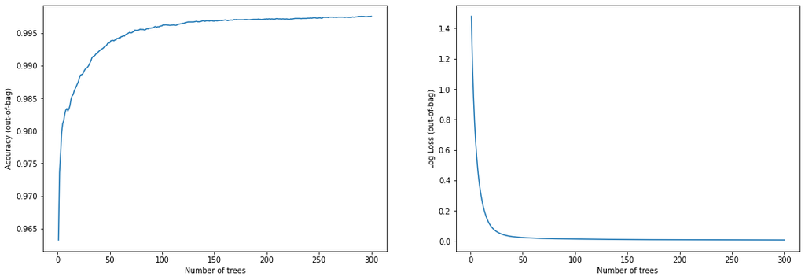

```python
logs = GBT_model.make_inspector().training_logs()

plt.figure(figsize=(18, 6))
plt.subplot(1, 2, 1)
plt.plot([log.num_trees for log in logs], [log.evaluation.accuracy for log in logs])
plt.xlabel("Number of trees")
plt.ylabel("Accuracy (out-of-bag)")
plt.subplot(1, 2, 2)
plt.plot([log.num_trees for log in logs], [log.evaluation.loss for log in logs])
plt.xlabel("Number of trees")
plt.ylabel("Log Loss (out-of-bag)")
plt.show()
```

```python
# Plot the model using Google Colab
# tfdf.model_plotter.plot_model_in_colab(GBT_model)
```

```python
if NOTIFY_STATUS: status_notify("Task 3 - Train and Evaluate Models completed! "+datetime.now().strftime('%a %B %d, %Y %I:%M:%S %p'))
```

## Task 4 - Fine-tune and Improve Models

```python
if NOTIFY_STATUS: status_notify("Task 4 - Fine-tune and Improve Models has begun! "+datetime.now().strftime('%a %B %d, %Y %I:%M:%S %p'))
```

```python
for num_trees in [150, 300, 500]:
    # Define the baseline model for benchmarking
    START_TIME_MODULE = datetime.now()
    model_tune = tfdf.keras.GradientBoostedTreesModel(num_trees=num_trees, task=tfdf.keras.Task.CLASSIFICATION)
    model_tune.compile(metrics=DEFAULT_METRICS)

    # Train the model.
    model_tune.fit(x=tfds_train, verbose=False)

    evaluation = model_tune.evaluate(tfds_valid, return_dict=True)
    print()

    for name, value in evaluation.items():
        print(f"{name}: {value:.4f}")
    print ('Model optimization time:', (datetime.now() - START_TIME_MODULE), '\n')
```

[output not shown]

[output cut: 469 more lines]

```
[INFO gradient_boosted_trees.cc:1428] 	num-trees:139 train-loss:0.003915 train-accuracy:0.999663 valid-loss:0.010945 valid-accuracy:0.996842
[INFO gradient_boosted_trees.cc:1428] 	num-trees:141 train-loss:0.003820 train-accuracy:0.999674 valid-loss:0.010846 valid-accuracy:0.996774
[INFO gradient_boosted_trees.cc:1428] 	num-trees:143 train-loss:0.003723 train-accuracy:0.999678 valid-loss:0.010757 valid-accuracy:0.996842
[INFO gradient_boosted_trees.cc:1428] 	num-trees:145 train-loss:0.003620 train-accuracy:0.999697 valid-loss:0.010666 valid-accuracy:0.996808
[INFO gradient_boosted_trees.cc:1428] 	num-trees:147 train-loss:0.003510 train-accuracy:0.999720 valid-loss:0.010559 valid-accuracy:0.996876
[INFO gradient_boosted_trees.cc:1428] 	num-trees:149 train-loss:0.003428 train-accuracy:0.999727 valid-loss:0.010474 valid-accuracy:0.996808
[INFO gradient_boosted_trees.cc:1426] 	num-trees:150 train-loss:0.003374 train-accuracy:0.999746 valid-loss:0.010383 valid-accuracy:0.996808
[INFO gradient_boosted_trees.cc:229] Truncates the model to 1200 tree(s) i.e. 150  iteration(s).
[INFO gradient_boosted_trees.cc:263] Final model num-trees:150 valid-loss:0.010383 valid-accuracy:0.996808
[INFO kernel.cc:828] Export model in log directory: /tmp/tmpsvehsjn1
[INFO kernel.cc:836] Save model in resources
[INFO kernel.cc:988] Loading model from path
[INFO decision_forest.cc:590] Model loaded with 1200 root(s), 63738 node(s), and 174 input feature(s).
[INFO abstract_model.cc:993] Engine "GradientBoostedTreesGeneric" built
[INFO kernel.cc:848] Use fast generic engine
```

```
loss: 0.0000
accuracy: 0.9965
sparse_categorical_crossentropy: 0.0289
Model optimization time: 1:15:53.779901
```

[output not shown]

[output cut: 538 more lines]

```
[INFO gradient_boosted_trees.cc:1428] 	num-trees:289 train-loss:0.000720 train-accuracy:0.999943 valid-loss:0.007504 valid-accuracy:0.997521
[INFO gradient_boosted_trees.cc:1428] 	num-trees:291 train-loss:0.000706 train-accuracy:0.999943 valid-loss:0.007473 valid-accuracy:0.997555
[INFO gradient_boosted_trees.cc:1428] 	num-trees:293 train-loss:0.000694 train-accuracy:0.999943 valid-loss:0.007471 valid-accuracy:0.997521
[INFO gradient_boosted_trees.cc:1428] 	num-trees:295 train-loss:0.000682 train-accuracy:0.999943 valid-loss:0.007462 valid-accuracy:0.997487
[INFO gradient_boosted_trees.cc:1428] 	num-trees:297 train-loss:0.000670 train-accuracy:0.999943 valid-loss:0.007451 valid-accuracy:0.997521
[INFO gradient_boosted_trees.cc:1428] 	num-trees:299 train-loss:0.000659 train-accuracy:0.999943 valid-loss:0.007421 valid-accuracy:0.997521
[INFO gradient_boosted_trees.cc:1426] 	num-trees:300 train-loss:0.000652 train-accuracy:0.999943 valid-loss:0.007414 valid-accuracy:0.997555
[INFO gradient_boosted_trees.cc:229] Truncates the model to 2400 tree(s) i.e. 300  iteration(s).
[INFO gradient_boosted_trees.cc:263] Final model num-trees:300 valid-loss:0.007414 valid-accuracy:0.997555
[INFO kernel.cc:828] Export model in log directory: /tmp/tmpvovcizql
[INFO kernel.cc:836] Save model in resources
[INFO kernel.cc:988] Loading model from path
[INFO decision_forest.cc:590] Model loaded with 2400 root(s), 122276 node(s), and 174 input feature(s).
[INFO abstract_model.cc:993] Engine "GradientBoostedTreesGeneric" built
[INFO kernel.cc:848] Use fast generic engine
```

[output not shown]

[output not shown]

```
loss: 0.0000
accuracy: 0.9976
sparse_categorical_crossentropy: 0.0248
Model optimization time: 2:26:55.958773
```

[output not shown]

[output cut: 545 more lines]

```
[INFO gradient_boosted_trees.cc:1428] 	num-trees:304 train-loss:0.000630 train-accuracy:0.999943 valid-loss:0.007349 valid-accuracy:0.997623
[INFO gradient_boosted_trees.cc:1428] 	num-trees:306 train-loss:0.000618 train-accuracy:0.999943 valid-loss:0.007331 valid-accuracy:0.997589
[INFO gradient_boosted_trees.cc:1428] 	num-trees:308 train-loss:0.000608 train-accuracy:0.999943 valid-loss:0.007313 valid-accuracy:0.997555
[INFO gradient_boosted_trees.cc:1428] 	num-trees:310 train-loss:0.000596 train-accuracy:0.999943 valid-loss:0.007294 valid-accuracy:0.997555
[INFO gradient_boosted_trees.cc:1428] 	num-trees:312 train-loss:0.000586 train-accuracy:0.999943 valid-loss:0.007289 valid-accuracy:0.997555
[INFO gradient_boosted_trees.cc:1428] 	num-trees:314 train-loss:0.000572 train-accuracy:0.999943 valid-loss:0.007282 valid-accuracy:0.997555
[INFO gradient_boosted_trees.cc:2740] Early stop of the training because the validation loss does not decrease anymore. Best valid-loss: 0.00727739
[INFO gradient_boosted_trees.cc:229] Truncates the model to 2488 tree(s) i.e. 311  iteration(s).
[INFO gradient_boosted_trees.cc:263] Final model num-trees:311 valid-loss:0.007277 valid-accuracy:0.997555
[INFO kernel.cc:828] Export model in log directory: /tmp/tmpf_pphpve
[INFO kernel.cc:836] Save model in resources
[INFO kernel.cc:988] Loading model from path
[INFO decision_forest.cc:590] Model loaded with 2488 root(s), 126436 node(s), and 174 input feature(s).
[INFO abstract_model.cc:993] Engine "GradientBoostedTreesGeneric" built
[INFO kernel.cc:848] Use fast generic engine
```

[output not shown]

[output not shown]

```
loss: 0.0000
accuracy: 0.9976
sparse_categorical_crossentropy: 0.0221
Model optimization time: 2:31:03.898310
```

```python
if NOTIFY_STATUS: status_notify("Task 4 - Fine-tune and Improve Models completed! "+datetime.now().strftime('%a %B %d, %Y %I:%M:%S %p'))
```

## Task 5 - Finalize Model and Make Predictions

```python
if NOTIFY_STATUS: status_notify("Task 5 - Finalize Model and Make Predictions has begun! "+datetime.now().strftime('%a %B %d, %Y %I:%M:%S %p'))
```

### 5.a) Train the Final Model

```python
# Finalize the training and validation datasets for the modeling activities
tfds_train = tfdf.keras.pd_dataframe_to_tf_dataset(df_dataset_import, label='target', task=tfdf.keras.Task.CLASSIFICATION)
```

```python
# Define the baseline model for benchmarking
START_TIME_MODULE = datetime.now()
final_model = tfdf.keras.GradientBoostedTreesModel(num_trees=500, task=tfdf.keras.Task.CLASSIFICATION)
final_model.compile(metrics=DEFAULT_METRICS)

# Train the model.
final_model.fit(x=tfds_train)
print ('Model training time:', (datetime.now() - START_TIME_MODULE), '\n')
```

[output not shown]

[output cut: 706 more lines]

```
[INFO gradient_boosted_trees.cc:1428] 	num-trees:314 train-loss:0.000658 train-accuracy:0.999911 valid-loss:0.007649 valid-accuracy:0.997981
[INFO gradient_boosted_trees.cc:1428] 	num-trees:315 train-loss:0.000651 train-accuracy:0.999911 valid-loss:0.007639 valid-accuracy:0.997981
[INFO gradient_boosted_trees.cc:1428] 	num-trees:316 train-loss:0.000646 train-accuracy:0.999911 valid-loss:0.007626 valid-accuracy:0.997981
[INFO gradient_boosted_trees.cc:1428] 	num-trees:317 train-loss:0.000639 train-accuracy:0.999911 valid-loss:0.007616 valid-accuracy:0.998011
[INFO gradient_boosted_trees.cc:1428] 	num-trees:318 train-loss:0.000633 train-accuracy:0.999911 valid-loss:0.007611 valid-accuracy:0.998011
[INFO gradient_boosted_trees.cc:1428] 	num-trees:319 train-loss:0.000627 train-accuracy:0.999911 valid-loss:0.007602 valid-accuracy:0.998073
[INFO gradient_boosted_trees.cc:1428] 	num-trees:320 train-loss:0.000624 train-accuracy:0.999911 valid-loss:0.007603 valid-accuracy:0.998073
[INFO gradient_boosted_trees.cc:1428] 	num-trees:321 train-loss:0.000619 train-accuracy:0.999911 valid-loss:0.007602 valid-accuracy:0.998073
[INFO gradient_boosted_trees.cc:1428] 	num-trees:322 train-loss:0.000615 train-accuracy:0.999911 valid-loss:0.007608 valid-accuracy:0.998042
[INFO gradient_boosted_trees.cc:2740] Early stop of the training because the validation loss does not decrease anymore. Best valid-loss: 0.0076019
[INFO gradient_boosted_trees.cc:229] Truncates the model to 2552 tree(s) i.e. 319  iteration(s).
[INFO gradient_boosted_trees.cc:263] Final model num-trees:319 valid-loss:0.007602 valid-accuracy:0.998073
[INFO kernel.cc:828] Export model in log directory: /tmp/tmpytlv8de1
[INFO kernel.cc:836] Save model in resources
[INFO kernel.cc:988] Loading model from path
```

```
[INFO decision_forest.cc:590] Model loaded with 2552 root(s), 131112 node(s), and 174 input feature(s).
[INFO abstract_model.cc:993] Engine "GradientBoostedTreesGeneric" built
[INFO kernel.cc:848] Use fast generic engine
```

```
Model training time: 2:57:31.824599
```

```python
final_model.summary()
```

```
Model: "gradient_boosted_trees_model_4"
_________________________________________________________________
 Layer (type)                Output Shape              Param #
=================================================================
=================================================================
Total params: 1
Trainable params: 0
Non-trainable params: 1
_________________________________________________________________
Type: "GRADIENT_BOOSTED_TREES"
Task: CLASSIFICATION
Label: "__LABEL"

Input Features (174):
	f1
	f10
	f100
	f101
	f102
	f103
	f104
	f105
	f106
	f107
	f108
	f109
	f11
	f110
	f111
	f112
	f113
	f114
	f115
	f116
	f117
	f118
	f119
	f12
	f120
	f121
```

[output cut: 1905 more lines]

```
	82 : f126 [NUMERICAL]
	64 : f127 [NUMERICAL]

Condition type in nodes:
	64280 : HigherCondition
Condition type in nodes with depth <= 0:
	2551 : HigherCondition
Condition type in nodes with depth <= 1:
	7624 : HigherCondition
Condition type in nodes with depth <= 2:
	17244 : HigherCondition
Condition type in nodes with depth <= 3:
	34617 : HigherCondition
Condition type in nodes with depth <= 5:
	64280 : HigherCondition
```

### 5.b) Load Test Dataset and Make Predictions

```python
# Finalize the test dataset for the prediction activities
tfds_test = tfdf.keras.pd_dataframe_to_tf_dataset(df_features_test, task=tfdf.keras.Task.CLASSIFICATION)
array_target_test = df_target_test.ravel()
```

```python
# Make batched predictions
test_predictions = np.argmax(final_model.predict(tfds_test), axis=-1)
print(test_predictions)
```

```
[1 1 4 ... 3 4 1]
```

```python
print('Accuracy Score:', accuracy_score(array_target_test, test_predictions), '\n')
print(confusion_matrix(array_target_test, test_predictions), '\n')
print(classification_report(array_target_test, test_predictions))
```

```
Accuracy Score: 0.9996777510089463

[[ 7880     0     0     0     0     1     1]
 [    0   733     0     0     0     0     0]
 [    0     0 14982     0     0     0     0]
 [    1     0     0 14804     3     0     0]
 [    0     0     0     7  9436     4     0]
 [    0     0     0     0     2 17067     0]
 [    2     0     0     0     0     0   244]]

              precision    recall  f1-score   support

           1       1.00      1.00      1.00      7882
           2       1.00      1.00      1.00       733
           3       1.00      1.00      1.00     14982
           4       1.00      1.00      1.00     14808
           5       1.00      1.00      1.00      9447
           6       1.00      1.00      1.00     17069
           7       1.00      0.99      0.99       246

    accuracy                           1.00     65167
   macro avg       1.00      1.00      1.00     65167
weighted avg       1.00      1.00      1.00     65167
```

```python
if NOTIFY_STATUS: status_notify("Task 5 - Finalize Model and Make Predictions completed! "+datetime.now().strftime('%a %B %d, %Y %I:%M:%S %p'))
```

```python
print ('Total time for the script:',(datetime.now() - START_TIME_SCRIPT))
```

```
Total time for the script: 20:41:33.867665
```